[figure not shown]

# Face Mask Prediction using U-Net

Task is to predict the mask around the face in a given image.

# Instructions

- Some part of the code is already done for you
- You need to execute all the cells
- You need to add the code where ever you see `"#### Add your code here ####"`
- Marks are mentioned along with the cells

## Dataset

Faces in images marked with bounding boxes. Have around 409 images with around 1000 faces manually tagged via bounding box.

- Data file name: images.npy

### Mount Google drive if you are using google colab

- We recommend using Google Colab as you can face memory issues and longer runtimes while running on local

```python
#### Add your code here ####

from google.colab import drive
drive.mount('/content/drive')
```

### Load the "images.npy" file (2 marks)

- This file contains images with details of bounding boxes

```python
import numpy as np
data = np.load('/content/drive/My Drive/advanced_computer_vision/images.npy', allow_pickle = True)#### Add your code here ####
```

### Check one sample from the loaded "images.npy" file (2 marks)

- Hint: print data[10][1]

```python
#### Add your code here ####
print(data[10][1])
```

```
[{'label': ['Face'], 'notes': '', 'points': [{'x': 0.48, 'y': 0.10385756676557864}, {'x': 0.7716666666666666, 'y': 0.6795252225519288}], 'imageWidth': 600, 'imageHeight': 337}]
```

```python
print(data[1][1])
```

```
[{'label': ['Face'], 'notes': '', 'points': [{'x': 0.7053087757313109, 'y': 0.23260437375745527}, {'x': 0.7692307692307693, 'y': 0.36182902584493043}], 'imageWidth': 1280, 'imageHeight': 697}]
```

```python
len(data)
```

```
409
```

```python
data.shape
```

```
(409, 2)
```

```python
# import  matplotlib.pyplot as plt

# plt.imshow(np.array(data[1]))
# plt.imshow()
```

```python
data[1]
```

[output not shown]

### Set image dimensions (1 mark)

- Initialize image height, image width with value: 224

```python
#### Add your code here ####

IMAGE_HEIGHT = 224
IMAGE_WIDTH = 224
```

### Create features and labels

- Here feature is the image
- The label is the mask
- Images will be stored in "X" array
- Masks will be stored in "masks" array

```python
import cv2
from tensorflow.keras.applications.mobilenet import preprocess_input

masks = np.zeros((int(data.shape[0]), IMAGE_HEIGHT, IMAGE_WIDTH))
X = np.zeros((int(data.shape[0]), IMAGE_HEIGHT, IMAGE_WIDTH, 3))
for index in range(data.shape[0]):
    img = data[index][0]
    img = cv2.resize(img, dsize=(IMAGE_HEIGHT, IMAGE_WIDTH), interpolation=cv2.INTER_CUBIC)
    try:
      img = img[:, :, :3]
    except:
      continue
    X[index] = preprocess_input(np.array(img, dtype=np.float32))
    for i in data[index][1]:
        x1 = int(i["points"][0]['x'] * IMAGE_WIDTH)
        x2 = int(i["points"][1]['x'] * IMAGE_WIDTH)
        y1 = int(i["points"][0]['y'] * IMAGE_HEIGHT)
        y2 = int(i["points"][1]['y'] * IMAGE_HEIGHT)
        masks[index][y1:y2, x1:x2] = 1
```

```python
data[11][1]
```

```
[{'imageHeight': 960,
  'imageWidth': 648,
  'label': ['Face'],
  'notes': '',
  'points': [{'x': 0.046296296296296294, 'y': 0.16354166666666667},
   {'x': 0.2037037037037037, 'y': 0.2989583333333333}]},
 {'imageHeight': 960,
  'imageWidth': 648,
  'label': ['Face'],
  'notes': '',
  'points': [{'x': 0.3194444444444444, 'y': 0.1375},
   {'x': 0.5570987654320988, 'y': 0.29583333333333334}]},
 {'imageHeight': 960,
  'imageWidth': 648,
  'label': ['Face'],
  'notes': '',
  'points': [{'x': 0.5648148148148148, 'y': 0.1875},
   {'x': 0.7145061728395061, 'y': 0.30520833333333336}]},
 {'imageHeight': 960,
  'imageWidth': 648,
  'label': ['Face'],
  'notes': '',
  'points': [{'x': 0.7160493827160493, 'y': 0.209375},
   {'x': 0.8333333333333334, 'y': 0.30625}]},
 {'imageHeight': 960,
  'imageWidth': 648,
  'label': ['Face'],
  'notes': '',
  'points': [{'x': 0.8225308641975309, 'y': 0.23125},
   {'x': 0.9429012345679012, 'y': 0.3177083333333333}]}]
```

```python
masks[11][1]
```

```
array([0., 0., 0., 0., 0., 0., 0., 0., 0., 0., 0., 0., 0., 0., 0., 0., 0.,
       0., 0., 0., 0., 0., 0., 0., 0., 0., 0., 0., 0., 0., 0., 0., 0., 0.,
       0., 0., 0., 0., 0., 0., 0., 0., 0., 0., 0., 0., 0., 0., 0., 0., 0.,
       0., 0., 0., 0., 0., 0., 0., 0., 0., 0., 0., 0., 0., 0., 0., 0., 0.,
       0., 0., 0., 0., 0., 0., 0., 0., 0., 0., 0., 0., 0., 0., 0., 0., 0.,
       0., 0., 0., 0., 0., 0., 0., 0., 0., 0., 0., 0., 0., 0., 0., 0., 0.,
       0., 0., 0., 0., 0., 0., 0., 0., 0., 0., 0., 0., 0., 0., 0., 0., 0.,
       0., 0., 0., 0., 0., 0., 0., 0., 0., 0., 0., 0., 0., 0., 0., 0., 0.,
       0., 0., 0., 0., 0., 0., 0., 0., 0., 0., 0., 0., 0., 0., 0., 0., 0.,
       0., 0., 0., 0., 0., 0., 0., 0., 0., 0., 0., 0., 0., 0., 0., 0., 0.,
       0., 0., 0., 0., 0., 0., 0., 0., 0., 0., 0., 0., 0., 0., 0., 0., 0.,
       0., 0., 0., 0., 0., 0., 0., 0., 0., 0., 0., 0., 0., 0., 0., 0., 0.,
       0., 0., 0., 0., 0., 0., 0., 0., 0., 0., 0., 0., 0., 0., 0., 0., 0.,
       0., 0., 0.])
```

### Split the data into training and testing (2 marks)

- 400 images in training
- 9 images in testing data

Training data

```python
X_train = X[:400]#### Add your code here ####
y_train = masks[:400]#### Add your code here ####
```

Testing data

```python
X_test = X[400:]#### Add your code here ####
y_test = masks[400:]#### Add your code here ####
```

```python
X_train.shape
```

```
(400, 224, 224, 3)
```

```python
y_train.shape
```

```
(400, 224, 224)
```

### Print a sample training image, image array and its mask (2 marks)

Print the image and image array

```
Clipping input data to the valid range for imshow with RGB data ([0..1] for floats or [0..255] for integers).
```

[figure not shown]

```python
#### Add your code here ####
import matplotlib.pyplot as plt

plt.imshow(X_train[100])
```

Print the mask

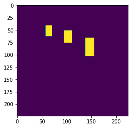

```python
#### Add your code here ####
plt.imshow(y_train[100])
```

## Create the model (5 marks)

- Add MobileNet as model with below parameter values
  - input_shape: IMAGE_HEIGHT, IMAGE_WIDTH, 3
  - include_top: False
  - alpha: 1.0
  - weights: "imagenet"
- Add UNET architecture layers
  - This is the trickiest part of the project, you need to research and implement it correctly

```python
from tensorflow.keras.applications.mobilenet import MobileNet
from tensorflow.keras.layers import Reshape, UpSampling2D, Concatenate, Conv2D
from tensorflow.keras.models import Model

def create_model(trainable=True):
    model = MobileNet(input_shape=(IMAGE_HEIGHT, IMAGE_WIDTH, 3), include_top=False, alpha=1.0, weights="imagenet")

    for layer in model.layers:
        layer.trainable = trainable

    block0 = model.get_layer('conv_pw_1_relu').output
    block1 = model.get_layer('conv_pw_3_relu').output
    block2 = model.get_layer('conv_pw_5_relu').output
    block3 = model.get_layer('conv_pw_11_relu').output
    block4 = model.get_layer('conv_pw_13_relu').output

    #### Add your code here ####

    deconv1 = Concatenate()([UpSampling2D()(block4), block3])
    deconv2 = Concatenate()([UpSampling2D()(deconv1), block2])
    deconv3 = Concatenate()([UpSampling2D()(deconv2), block1])
    deconv4 = Concatenate()([UpSampling2D()(deconv3), block0])
    x = UpSampling2D()(deconv4)

    x = Conv2D(1, kernel_size = 1, activation = 'sigmoid')(x)

    return Model(model.input, outputs= x)
```

```python
model = MobileNet(input_shape=(IMAGE_HEIGHT, IMAGE_WIDTH, 3), include_top=False, alpha=1.0, weights="imagenet")
model.summary()
```

```
Model: "mobilenet_1.00_224"
_________________________________________________________________
Layer (type)                 Output Shape              Param #
=================================================================
input_1 (InputLayer)         [(None, 224, 224, 3)]     0
_________________________________________________________________
conv1_pad (ZeroPadding2D)    (None, 225, 225, 3)       0
_________________________________________________________________
conv1 (Conv2D)               (None, 112, 112, 32)      864
_________________________________________________________________
conv1_bn (BatchNormalization (None, 112, 112, 32)      128
_________________________________________________________________
conv1_relu (ReLU)            (None, 112, 112, 32)      0
_________________________________________________________________
conv_dw_1 (DepthwiseConv2D)  (None, 112, 112, 32)      288
_________________________________________________________________
conv_dw_1_bn (BatchNormaliza (None, 112, 112, 32)      128
_________________________________________________________________
conv_dw_1_relu (ReLU)        (None, 112, 112, 32)      0
_________________________________________________________________
conv_pw_1 (Conv2D)           (None, 112, 112, 64)      2048
_________________________________________________________________
conv_pw_1_bn (BatchNormaliza (None, 112, 112, 64)      256
_________________________________________________________________
conv_pw_1_relu (ReLU)        (None, 112, 112, 64)      0
_________________________________________________________________
conv_pad_2 (ZeroPadding2D)   (None, 113, 113, 64)      0
_________________________________________________________________
conv_dw_2 (DepthwiseConv2D)  (None, 56, 56, 64)        576
_________________________________________________________________
conv_dw_2_bn (BatchNormaliza (None, 56, 56, 64)        256
_________________________________________________________________
conv_dw_2_relu (ReLU)        (None, 56, 56, 64)        0
_________________________________________________________________
conv_pw_2 (Conv2D)           (None, 56, 56, 128)       8192
_________________________________________________________________
conv_pw_2_bn (BatchNormaliza (None, 56, 56, 128)       512
_________________________________________________________________
conv_pw_2_relu (ReLU)        (None, 56, 56, 128)       0
_________________________________________________________________
```

[output cut: 127 more lines]

```
_________________________________________________________________
conv_dw_13_bn (BatchNormaliz (None, 7, 7, 1024)        4096
_________________________________________________________________
conv_dw_13_relu (ReLU)       (None, 7, 7, 1024)        0
_________________________________________________________________
conv_pw_13 (Conv2D)          (None, 7, 7, 1024)        1048576
_________________________________________________________________
conv_pw_13_bn (BatchNormaliz (None, 7, 7, 1024)        4096
_________________________________________________________________
conv_pw_13_relu (ReLU)       (None, 7, 7, 1024)        0
=================================================================
Total params: 3,228,864
Trainable params: 3,206,976
Non-trainable params: 21,888
_________________________________________________________________
```

### Call the create_model function (1 mark)

- Give trainable=False as argument, if you want to freeze lower layers for fast training (but low accuracy)

```python
#### Add your code here ####
model = create_model()
```

### Print model summary (1 mark)

```python
#### Add your code here ####
model.summary()
```

```
Model: "functional_1"
__________________________________________________________________________________________________
Layer (type)                    Output Shape         Param #     Connected to
==================================================================================================
input_2 (InputLayer)            [(None, 224, 224, 3) 0
__________________________________________________________________________________________________
conv1_pad (ZeroPadding2D)       (None, 225, 225, 3)  0           input_2[0][0]
__________________________________________________________________________________________________
conv1 (Conv2D)                  (None, 112, 112, 32) 864         conv1_pad[0][0]
__________________________________________________________________________________________________
conv1_bn (BatchNormalization)   (None, 112, 112, 32) 128         conv1[0][0]
__________________________________________________________________________________________________
conv1_relu (ReLU)               (None, 112, 112, 32) 0           conv1_bn[0][0]
__________________________________________________________________________________________________
conv_dw_1 (DepthwiseConv2D)     (None, 112, 112, 32) 288         conv1_relu[0][0]
__________________________________________________________________________________________________
conv_dw_1_bn (BatchNormalizatio (None, 112, 112, 32) 128         conv_dw_1[0][0]
__________________________________________________________________________________________________
conv_dw_1_relu (ReLU)           (None, 112, 112, 32) 0           conv_dw_1_bn[0][0]
__________________________________________________________________________________________________
conv_pw_1 (Conv2D)              (None, 112, 112, 64) 2048        conv_dw_1_relu[0][0]
__________________________________________________________________________________________________
conv_pw_1_bn (BatchNormalizatio (None, 112, 112, 64) 256         conv_pw_1[0][0]
__________________________________________________________________________________________________
conv_pw_1_relu (ReLU)           (None, 112, 112, 64) 0           conv_pw_1_bn[0][0]
__________________________________________________________________________________________________
conv_pad_2 (ZeroPadding2D)      (None, 113, 113, 64) 0           conv_pw_1_relu[0][0]
__________________________________________________________________________________________________
conv_dw_2 (DepthwiseConv2D)     (None, 56, 56, 64)   576         conv_pad_2[0][0]
__________________________________________________________________________________________________
conv_dw_2_bn (BatchNormalizatio (None, 56, 56, 64)   256         conv_dw_2[0][0]
__________________________________________________________________________________________________
conv_dw_2_relu (ReLU)           (None, 56, 56, 64)   0           conv_dw_2_bn[0][0]
__________________________________________________________________________________________________
conv_pw_2 (Conv2D)              (None, 56, 56, 128)  8192        conv_dw_2_relu[0][0]
__________________________________________________________________________________________________
conv_pw_2_bn (BatchNormalizatio (None, 56, 56, 128)  512         conv_pw_2[0][0]
__________________________________________________________________________________________________
conv_pw_2_relu (ReLU)           (None, 56, 56, 128)  0           conv_pw_2_bn[0][0]
__________________________________________________________________________________________________
```

[output cut: 151 more lines]

```
                                                                 conv_pw_3_relu[0][0]
__________________________________________________________________________________________________
up_sampling2d_3 (UpSampling2D)  (None, 112, 112, 192 0           concatenate_2[0][0]
__________________________________________________________________________________________________
concatenate_3 (Concatenate)     (None, 112, 112, 198 0           up_sampling2d_3[0][0]
                                                                 conv_pw_1_relu[0][0]
__________________________________________________________________________________________________
up_sampling2d_4 (UpSampling2D)  (None, 224, 224, 198 0           concatenate_3[0][0]
__________________________________________________________________________________________________
conv2d (Conv2D)                 (None, 224, 224, 1)  1985        up_sampling2d_4[0][0]
==================================================================================================
Total params: 3,230,849
Trainable params: 3,208,961
Non-trainable params: 21,888
__________________________________________________________________________________________________
```

### Define dice coefficient function (2 marks)

- Create a function to calculate dice coefficient

```python
#### Add your code here ####

# from keras import backend as K
# def iou_coef(y_true, y_pred, smooth=1):
#   intersection = K.sum(K.abs(y_true * y_pred), axis=[1,2,3])
#   union = K.sum(y_true,[1,2,3])+K.sum(y_pred,[1,2,3])-intersection
#   iou = K.mean((intersection + smooth) / (union + smooth), axis=0)
#   return iou


# def dice_coef(y_true, y_pred, smooth=1):
#   intersection = K.sum(y_true * y_pred, axis=[1,2,3])
#   union = K.sum(y_true, axis=[1,2,3]) + K.sum(y_pred, axis=[1,2,3])
#   dice = K.mean((2. * intersection + smooth)/(union + smooth), axis=0)
#   return dice

from tensorflow.math import reduce_sum

# def cal_dice_coef(y_train, y_pred):
#   intersection = reduce_sum(y_train*y_pred,axis=[1,2,3])
#   union = reduce_sum(y_train,axis = [1,2,3]),reduce_sum( y_pred, axis = [1,2,3])
#   iou = reduce_mean((2. * intersection + smooth)/(union + smooth), axis=0)
#   return iou


def cal_dice_coef(y_train, y_pred):
  intersection = reduce_sum(y_train*y_pred)
  union = reduce_sum(y_train + y_pred)
  return (2. * intersection + 0.00001)/(union + 0.00001)
```

### Define loss function (2 marks)

```python
#### Add your code here ####

def dice_loss(y_test, y_pred):
  return 1 - cal_dice_coef(y_test, y_pred)
```

### Compile the model (2 marks)

- Complie the model using below parameters
  - loss: use the loss function defined above
  - optimizers: use Adam optimizer
  - metrics: use dice_coefficient function defined above

```python
#### Add your code here ####

model.compile(optimizer = 'adam',
              metrics = [cal_dice_coef],
              loss = dice_loss)
```

### Define callbacks (2 marks)

- Use ModelCheckpoint
- Use EarlyStopping
- Use ReduceLROnPlateau

```python
#### Add your code here ####
from tensorflow.keras.callbacks import ModelCheckpoint, EarlyStopping, ReduceLROnPlateau

checkpoint = ModelCheckpoint(mode = 'min',
                             filepath='checkpoint.h5',
                             monitor='loss',
                             save_best_only='True',
                             save_weights_only='True',
                             verbose=1)
earlystopping = EarlyStopping(mode = 'min',
                              monitor=dice_loss,
                              patience=5,
                              verbose=1)
reduce_lr = ReduceLROnPlateau(mode = 'min',
                              monitor='loss',
                              factor=0.2,
                              patience=2,
                              min_lr=0.0001)
```

### Fit the model (2 marks)

- Fit the model using below parameters
  - epochs: you can decide
  - batch_size: 1
  - callbacks: use the callbacks defined above

```python
#### Add your code here ####

model.fit(X_train,
          y_train,
          epochs = 10,
          batch_size = 1,
          callbacks = [checkpoint,earlystopping,reduce_lr])
```

[output not shown]

```
<tensorflow.python.keras.callbacks.History at 0x7fbaa6595a58>
```

### Get the predicted mask for a test image (2 marks)

Show the test image

```
Clipping input data to the valid range for imshow with RGB data ([0..1] for floats or [0..255] for integers).
```

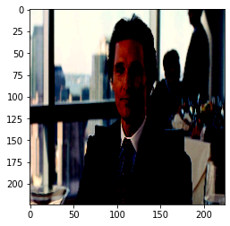

```python
#### Add your code here ####
plt.imshow(X_test[3])
```

Show original mask for test image

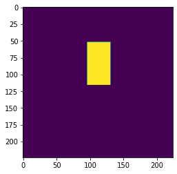

```python
#### Add your code here ####
plt.imshow(y_test[3])
```

```python
#### Add your code here ####
m=8
pred_mask = model.predict(x=np.array([X_test[m]]))[0] > 0.5
```

### Impose the mask on the test image (2 marks)

- In imshow use the alpha parameter and set it to greater than 0.5

```
Clipping input data to the valid range for imshow with RGB data ([0..1] for floats or [0..255] for integers).
```

[figure not shown]

```python
#### Add your code here ####
plt.imshow(X_test[m])
plt.imshow(pred_mask[:,:,0], alpha = 0.7)
```